# Big Data Computation Final Project

Balla Diaite

2024-12-18

## Introduction

The Crash Report Sampling System (CRSS) dataset provides comprehensive information on crashes in the United States. This analysis seeks to uncover key factors influencing road safety and identify actionable strategies to reduce accidents and improve travel safety. The dataset includes crash-level data, individual-level data, and vehicle-level data for crashes occurring between 2020 and 2022.

**Objectives:**

1. To identify patterns and trends in crash occurrences.
2. To examine demographic, environmental, and vehicle-related factors contributing to crashes.
3. To provide actionable recommendations for improving road safety.

## Load Libraries

```r
# Load Libraries
library(tidyverse)
```

```r
library(readr)
library(dplyr)
library(ggplot2)
library(lubridate)
library(scales)
library(RColorBrewer)
library(viridis)
library(forcats)
library(stringr)
```

## Read Data

```r
# Read datasets
accident_2022 <- read_csv("C:/Users/balla/Downloads/CRSS2022CSV/CRSS2022CSV/accident.csv")
person_2022   <- read_csv("C:/Users/balla/Downloads/CRSS2022CSV/CRSS2022CSV/person.csv")
vehicle_2022  <- read_csv("C:/Users/balla/Downloads/CRSS2022CSV/CRSS2022CSV/vehicle.csv")
accident_2021 <- read_csv("C:/Users/balla/Downloads/CRSS2021CSV/CRSS2021CSV/accident.csv")
person_2021   <- read_csv("C:/Users/balla/Downloads/CRSS2021CSV/CRSS2021CSV/person.csv")
vehicle_2021  <- read_csv("C:/Users/balla/Downloads/CRSS2021CSV/CRSS2021CSV/vehicle.csv")
accident_2020 <- read_csv("C:/Users/balla/Downloads/CRSS2020CSV/CRSS2020CSV/accident.csv")
person_2020   <- read_csv("C:/Users/balla/Downloads/CRSS2020CSV/CRSS2020CSV/person.csv")
vehicle_2020  <- read_csv("C:/Users/balla/Downloads/CRSS2020CSV/CRSS2020CSV/vehicle.csv")
# Combine datasets
accident <- bind_rows(accident_2020, accident_2021, accident_2022)
person   <- bind_rows(person_2020, person_2021, person_2022)
vehicle  <- bind_rows(vehicle_2020, vehicle_2021, vehicle_2022)

head(accident)
```

```
## # A tibble: 6 × 80
##     CASENUM STRATUM STRATUMNAME REGION REGIONNAME   PSU    PJ PSU_VAR URBANICITY
##       <dbl>   <dbl> <chr>        <dbl> <chr>      <dbl> <dbl>   <dbl>      <dbl>
## 1   2.02e11       9 Stratum 9 …      4 West (MT,…    20  4140      20          2
## 2   2.02e11       8 Stratum 8 …      3 South (MD…    28  4139      28          1
## 3   2.02e11       9 Stratum 9 …      3 South (MD…    12  4142      12          1
## 4   2.02e11      10 Stratum 10…      4 West (MT,…    20  4140      20          2
## 5   2.02e11      10 Stratum 10…      1 Northeast…    22  4149      22          2
## 6   2.02e11       8 Stratum 8 …      2 Midwest (…    77  4151      77          2
## # ℹ 71 more variables: URBANICITYNAME <chr>, VE_TOTAL <dbl>, VE_FORMS <dbl>,
## #   PVH_INVL <dbl>, PEDS <dbl>, PERMVIT <dbl>, PERNOTMVIT <dbl>, NUM_INJ <dbl>,
## #   NUM_INJNAME <chr>, MONTH <dbl>, MONTHNAME <chr>, YEAR <dbl>,
## #   YEARNAME <dbl>, DAY_WEEK <dbl>, DAY_WEEKNAME <chr>, HOUR <dbl>,
## #   HOURNAME <chr>, MINUTE <dbl>, MINUTENAME <chr>, HARM_EV <dbl>,
## #   HARM_EVNAME <chr>, ALCOHOL <dbl>, ALCOHOLNAME <chr>, MAX_SEV <dbl>,
## #   MAX_SEVNAME <chr>, MAN_COLL <dbl>, MAN_COLLNAME <chr>, RELJCT1 <dbl>, …
```

```r
head(person)
```

```
## # A tibble: 6 × 112
##       CASENUM VE_FORMS VEH_NO PER_NO STRATUM STRATUMNAME REGION REGIONNAME   PSU
##         <dbl>    <dbl>  <dbl>  <dbl>   <dbl> <chr>        <dbl> <chr>      <dbl>
## 1     2.02e11        2      1      1       9 Stratum 9 …      4 West (MT,…    20
## 2     2.02e11        2      2      1       9 Stratum 9 …      4 West (MT,…    20
## 3     2.02e11        1      1      1       8 Stratum 8 …      3 South (MD…    28
## 4     2.02e11        2      1      1       9 Stratum 9 …      3 South (MD…    12
## 5     2.02e11        2      2      1       9 Stratum 9 …      3 South (MD…    12
## 6     2.02e11        1      1      1      10 Stratum 10…      4 West (MT,…    20
## # ℹ 103 more variables: PJ <dbl>, PSU_VAR <dbl>, URBANICITY <dbl>,
## #   URBANICITYNAME <chr>, STR_VEH <dbl>, MONTH <dbl>, MONTHNAME <chr>,
## #   HOUR <dbl>, HOURNAME <chr>, MINUTE <dbl>, MINUTENAME <chr>, HARM_EV <dbl>,
## #   HARM_EVNAME <chr>, MAN_COLL <dbl>, MAN_COLLNAME <chr>, SCH_BUS <dbl>,
## #   SCH_BUSNAME <chr>, MAKE <dbl>, MAKENAME <chr>, MAK_MOD <dbl>,
## #   MAK_MODNAME <chr>, BODY_TYP <dbl>, BODY_TYPNAME <chr>, MOD_YEAR <dbl>,
## #   MOD_YEARNAME <chr>, TOW_VEH <dbl>, TOW_VEHNAME <chr>, SPEC_USE <dbl>, …
```

```r
head(vehicle)
```

```
## # A tibble: 6 × 171
##        CASENUM VEH_NO STRATUM STRATUMNAME  REGION REGIONNAME   PSU    PJ PSU_VAR
##          <dbl>  <dbl>   <dbl> <chr>         <dbl> <chr>      <dbl> <dbl>   <dbl>
## 1 202002121240      1       9 Stratum 9 -…      4 West (MT,…    20  4140      20
## 2 202002121240      2       9 Stratum 9 -…      4 West (MT,…    20  4140      20
## 3 202002121829      1       8 Stratum 8 -…      3 South (MD…    28  4139      28
## 4 202002121849      1       9 Stratum 9 -…      3 South (MD…    12  4142      12
## 5 202002121849      2       9 Stratum 9 -…      3 South (MD…    12  4142      12
## 6 202002123484      1      10 Stratum 10 …      4 West (MT,…    20  4140      20
## # ℹ 162 more variables: URBANICITY <dbl>, URBANICITYNAME <chr>, VE_FORMS <dbl>,
## #   NUMOCCS <dbl>, NUMOCCSNAME <chr>, MONTH <dbl>, MONTHNAME <chr>, HOUR <dbl>,
## #   HOURNAME <chr>, MINUTE <dbl>, MINUTENAME <chr>, HARM_EV <dbl>,
## #   HARM_EVNAME <chr>, MAN_COLL <dbl>, MAN_COLLNAME <chr>, UNITTYPE <dbl>,
## #   UNITTYPENAME <chr>, HIT_RUN <dbl>, HIT_RUNNAME <chr>, MAKE <dbl>,
## #   MAKENAME <chr>, MODEL <dbl>, MAK_MOD <dbl>, MAK_MODNAME <chr>,
## #   BODY_TYP <dbl>, BODY_TYPNAME <chr>, MOD_YEAR <dbl>, MOD_YEARNAME <chr>, …
```

## Clean and Prepare Data

```r
accident <- accident %>%
  select(CASENUM, REGIONNAME, URBANICITYNAME, WEATHERNAME, MONTHNAME, DAY_WEEKNAME, HOURNAME, MAX_SEVNAME, YEAR)

person <- person %>%
  select(CASENUM, AGE, SEXNAME, INJ_SEVNAME)

vehicle <- vehicle %>%
  select(CASENUM, MAKENAME, BODY_TYPNAME, VEH_ALCHNAME)

# Drop rows with missing values
accident <- accident %>% drop_na()
person <- person %>% drop_na()
vehicle <- vehicle %>% drop_na()
```

## Identify Areas of Interest and Questions

**Research Questions:**

1. **What is the distribution of crash severities?**
   - Analyze how different severities (e.g., fatal, serious injury, no injury) are distributed among crashes.
2. **What are the age distributions of individuals involved in crashes?**
   - Identify which age groups are most commonly involved in crashes, with age binned into ranges.
   - Compare age distributions by gender to observe potential patterns.
3. **How do weather conditions contribute to crashes?**
   - Explore which weather conditions (e.g., clear, cloudy, rain) are most associated with crashes.
   - Analyze the trends of weather conditions over the years.
4. **What are the trends in crash severity over three years?**
   - Examine trends for specific severities (Fatal Injury, Serious Injury, No Apparent Injury) over the years 2020-2022.
5. **How does urbanicity (urban vs. rural areas) influence crash severity?**
   - Compare crash severities between urban and rural areas.
6. **What are the peak hours for crashes?**
   - Determine the distribution of crashes across different hours of the day.
7. **What actionable insights can be drawn for improving road safety?**
   - Summarize key findings and propose recommendations to improve travel safety.

## Exploring Variables

**Crash Severity Table**

```r
severity_table <- accident %>%
  group_by(MAX_SEVNAME) %>%
  summarise(Count = n(), Percentage = round((n() / nrow(accident)) * 100, 2))

print(severity_table)
```

```
## # A tibble: 9 × 3
##   MAX_SEVNAME                  Count Percentage
##   <chr>                        <int>      <dbl>
## 1 Died Prior to Crash*             6       0
## 2 Fatal Injury (K)              3856       2.37
## 3 Injured, Severity Unknown      404       0.25
## 4 No Apparent Injury (O)       75072      46.1
## 5 No person involved              53       0.03
## 6 Possible Injury (C)          35181      21.6
## 7 Suspected Minor Injury (B)   27564      16.9
## 8 Suspected Serious Injury (A) 17843      11.0
## 9 Unknown/Not Reported          2921       1.79
```

**Crash Severity Distribution**

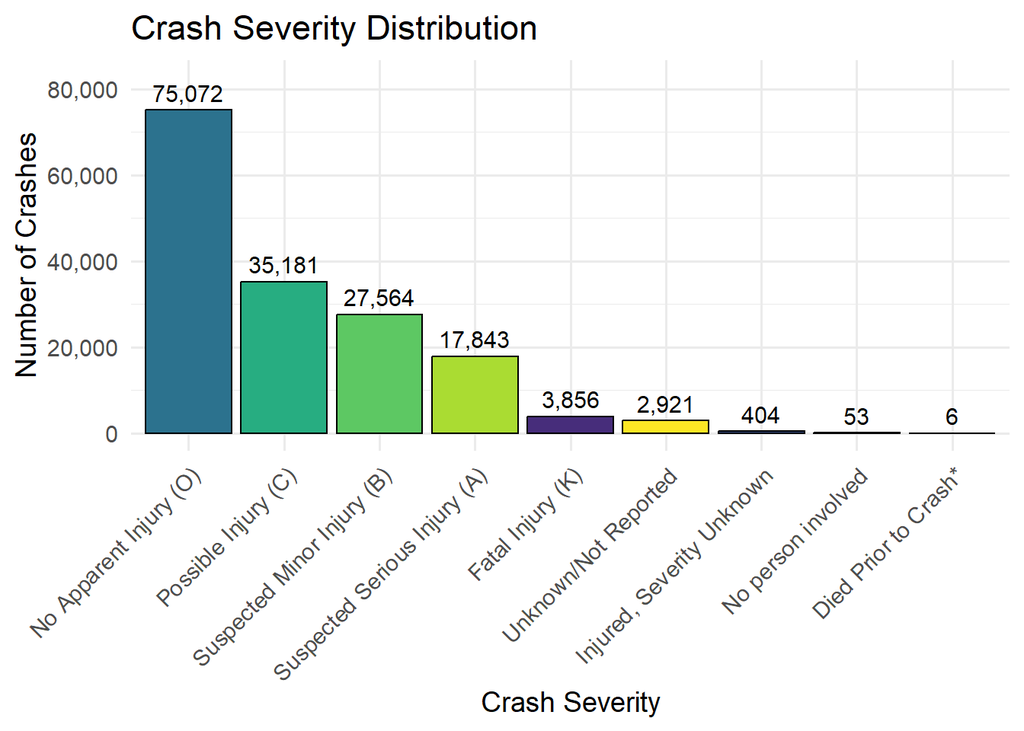

```r
severity_distribution <- accident %>%
  group_by(MAX_SEVNAME) %>%
  summarise(Count = n()) %>%
  arrange(desc(Count))

ggplot(severity_distribution, aes(x = reorder(MAX_SEVNAME, -Count), y = Count, fill = MAX_SEVNAME)) +
  geom_bar(stat = "identity", color = "black", show.legend = FALSE) +
  geom_text(aes(label = scales::comma(Count)), vjust = -0.5, size = 4) +
  scale_y_continuous(limits = c(0, max(severity_distribution$Count) * 1.1),
                     labels = scales::comma) +
  scale_fill_viridis(discrete = TRUE) +
  labs(title = "Crash Severity Distribution",
       x = "Crash Severity", y = "Number of Crashes") +
  theme_minimal(base_size = 14) +
  theme(axis.text.x = element_text(angle = 45, hjust = 1))
```

**Age Distribution**

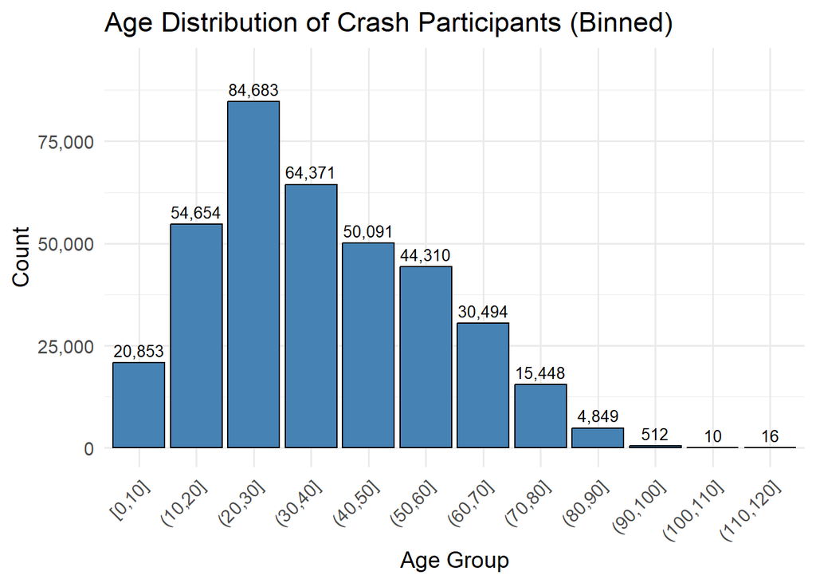

```r
age_binned <- person %>%
  filter(AGE >= 0 & AGE <= 120) %>%
  mutate(Age_Group = cut(AGE, breaks = seq(0, 120, by = 10), include.lowest = TRUE)) %>%
  group_by(Age_Group) %>%
  summarise(Count = n())

ggplot(age_binned, aes(x = Age_Group, y = Count)) +
  geom_bar(stat = "identity", fill = "steelblue", color = "black") +
  geom_text(aes(label = scales::comma(Count)), vjust = -0.5, size = 3.5) +
  scale_y_continuous(limits = c(0, max(age_binned$Count) * 1.1),
                     labels = scales::comma) +
  labs(title = "Age Distribution of Crash Participants (Binned)",
       x = "Age Group", y = "Count") +
  theme_minimal(base_size = 14) +
  theme(axis.text.x = element_text(angle = 45, hjust = 1))
```

**Weather Conditions Affecting Crashes**

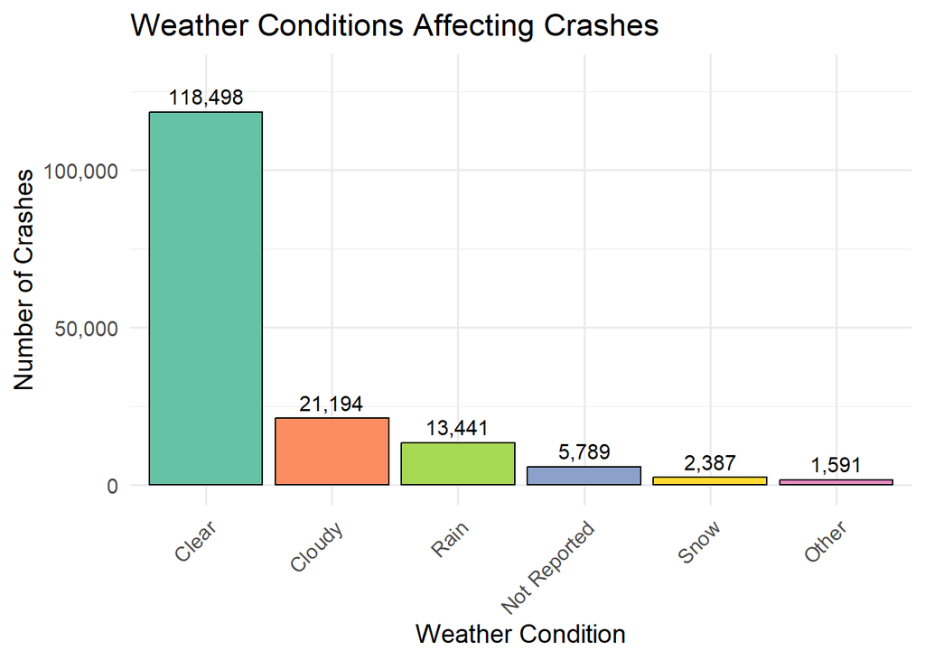

```r
weather_distribution <- accident %>%
  group_by(WEATHERNAME) %>%
  summarise(Count = n()) %>%
  mutate(WEATHERNAME = ifelse(Count < 1000, "Other", WEATHERNAME)) %>%
  group_by(WEATHERNAME) %>%
  summarise(Count = sum(Count)) %>%
  arrange(desc(Count))

ggplot(weather_distribution, aes(x = reorder(WEATHERNAME, -Count), y = Count, fill = WEATHERNAME)) +
  geom_bar(stat = "identity", color = "black", show.legend = FALSE) +
  geom_text(aes(label = scales::comma(Count)), vjust = -0.5, size = 4) +
  scale_y_continuous(limits = c(0, max(weather_distribution$Count) * 1.1),
                     labels = scales::comma) +
  scale_fill_brewer(palette = "Set2") +
  labs(title = "Weather Conditions Affecting Crashes",
       x = "Weather Condition", y = "Number of Crashes") +
  theme_minimal(base_size = 14) +
  theme(axis.text.x = element_text(angle = 45, hjust = 1))
```

**Gender Distribution of Crash Participants**

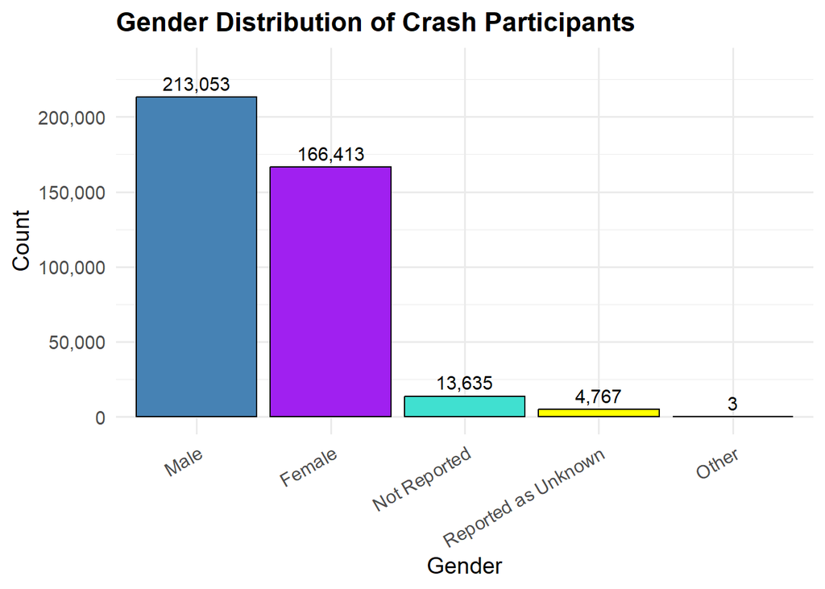

```r
gender_distribution <- person %>%
  group_by(SEXNAME) %>%
  summarise(Count = n())

# Clean long labels further
gender_distribution$SEXNAME <- str_replace_all(gender_distribution$SEXNAME,
                                               "Other \\(e\\.g\\., .*\\)", "Other")

ggplot(gender_distribution, aes(x = reorder(SEXNAME, -Count), y = Count, fill = SEXNAME)) +
  geom_bar(stat = "identity", color = "black", show.legend = FALSE) +
  geom_text(aes(label = scales::comma(Count)), vjust = -0.5, size = 4) +
  scale_y_continuous(limits = c(0, max(gender_distribution$Count) * 1.1),
                     labels = scales::comma) +
  scale_fill_manual(values = c("Male" = "steelblue", "Female" = "purple",
                               "Not Reported" = "turquoise", "Other" = "orange",
                               "Reported as Unknown" = "yellow")) +
  labs(title = "Gender Distribution of Crash Participants",
       x = "Gender", y = "Count") +
  theme_minimal(base_size = 14) +
  theme(axis.text.x = element_text(angle = 30, hjust = 1),
        axis.title.x = element_text(size = 14),
        axis.title.y = element_text(size = 14),
        plot.title = element_text(face = "bold", size = 16))
```

## Peak Hours for Crashes

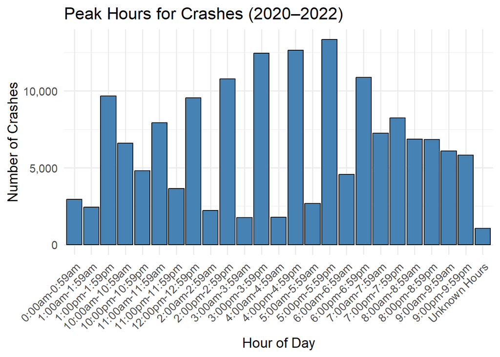

```r
hourly_crash <- accident %>%
  group_by(HOURNAME) %>%
  summarise(Count = n()) %>%
  mutate(HOURNAME = factor(HOURNAME, levels = unique(sort(HOURNAME, na.last = TRUE))))

ggplot(hourly_crash, aes(x = HOURNAME, y = Count)) +
  geom_bar(stat = "identity", fill = "steelblue", color = "black") +
  labs(title = "Peak Hours for Crashes (2020–2022)",
       x = "Hour of Day", y = "Number of Crashes") +
  scale_y_continuous(labels = scales::comma) +
  theme_minimal(base_size = 14) +
  theme(axis.text.x = element_text(angle = 45, hjust = 1))
```

## Contingency Tables

```r
# Contingency table: Crash Severity by Urbanicity
severity_by_urban <- accident %>%
  group_by(URBANICITYNAME, MAX_SEVNAME) %>%
  summarise(Count = n(), .groups = "drop")

print(severity_by_urban)
```

```
## # A tibble: 18 × 3
##    URBANICITYNAME MAX_SEVNAME                  Count
##    <chr>          <chr>                        <int>
##  1 Rural Area     Died Prior to Crash*             4
##  2 Rural Area     Fatal Injury (K)              1175
##  3 Rural Area     Injured, Severity Unknown       62
##  4 Rural Area     No Apparent Injury (O)       19563
##  5 Rural Area     No person involved              12
##  6 Rural Area     Possible Injury (C)           7063
##  7 Rural Area     Suspected Minor Injury (B)    6362
##  8 Rural Area     Suspected Serious Injury (A)  4558
##  9 Rural Area     Unknown/Not Reported          1021
## 10 Urban Area     Died Prior to Crash*             2
## 11 Urban Area     Fatal Injury (K)              2681
## 12 Urban Area     Injured, Severity Unknown      342
## 13 Urban Area     No Apparent Injury (O)       55509
## 14 Urban Area     No person involved              41
## 15 Urban Area     Possible Injury (C)          28118
## 16 Urban Area     Suspected Minor Injury (B)   21202
## 17 Urban Area     Suspected Serious Injury (A) 13285
## 18 Urban Area     Unknown/Not Reported          1900
```

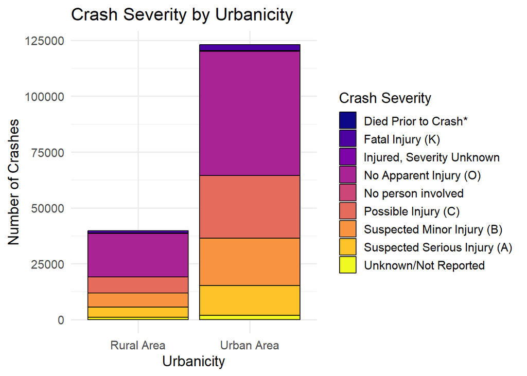

```r
ggplot(severity_by_urban, aes(x = URBANICITYNAME, y = Count, fill = MAX_SEVNAME)) +
  geom_bar(stat = "identity", position = "stack", color = "black") +
  scale_fill_viridis(discrete = TRUE, option = "C") +
  labs(title = "Crash Severity by Urbanicity",
       x = "Urbanicity", y = "Number of Crashes", fill = "Crash Severity") +
  theme_minimal(base_size = 14)
```

## Trends Over Three Years

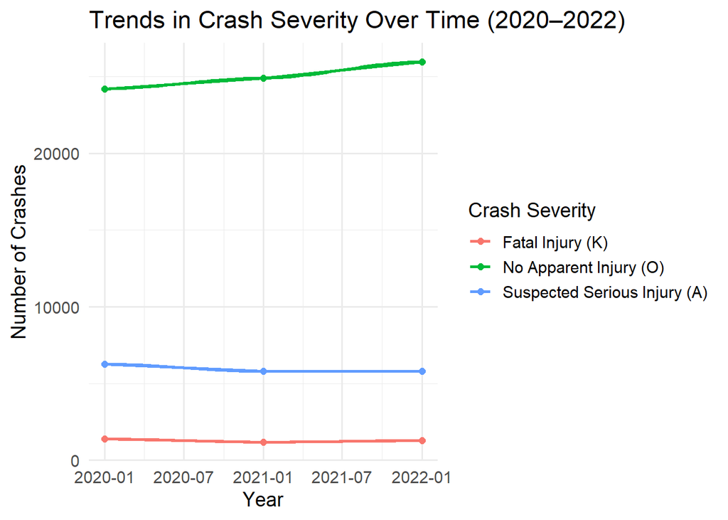

```r
yearly_trend <- accident %>%
  mutate(Date = make_date(YEAR)) %>%
  group_by(Date, MAX_SEVNAME) %>%
  summarise(Count = n(), .groups = "drop") %>%
  filter(MAX_SEVNAME %in% c("Fatal Injury (K)", "Suspected Serious Injury (A)", "No Apparent Injury (O)"))

ggplot(yearly_trend, aes(x = Date, y = Count, color = MAX_SEVNAME)) +
  geom_line(linewidth = 1) +
  geom_point(size = 2) +
  geom_smooth(se = FALSE, method = "loess") +
  labs(title = "Trends in Crash Severity Over Time (2020–2022)",
       x = "Year", y = "Number of Crashes", color = "Crash Severity") +
  theme_minimal(base_size = 14)
```

## Age Distribution by Gender

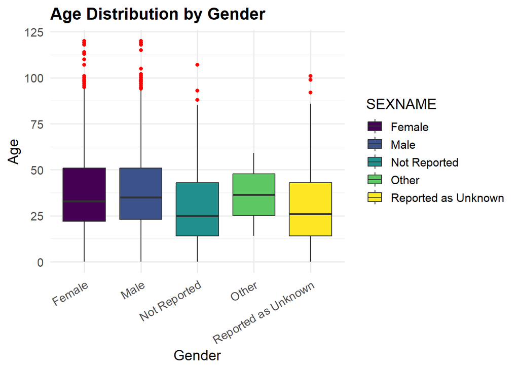

```r
person_clean <- person %>%
  filter(AGE >= 0 & AGE <= 120) %>%
  mutate(SEXNAME = case_when(
    str_detect(SEXNAME, "Other") ~ "Other",
    TRUE ~ SEXNAME
  ))

ggplot(person_clean, aes(x = SEXNAME, y = AGE, fill = SEXNAME)) +
  geom_boxplot(outlier.color = "red", outlier.shape = 16) +
  scale_fill_viridis(discrete = TRUE, option = "D") +
  labs(title = "Age Distribution by Gender",
       x = "Gender", y = "Age") +
  theme_minimal(base_size = 14) +
  theme(plot.title = element_text(face = "bold", size = 16),
        axis.text.x = element_text(angle = 30, hjust = 1))
```

## Weather Conditions and Crash Severity

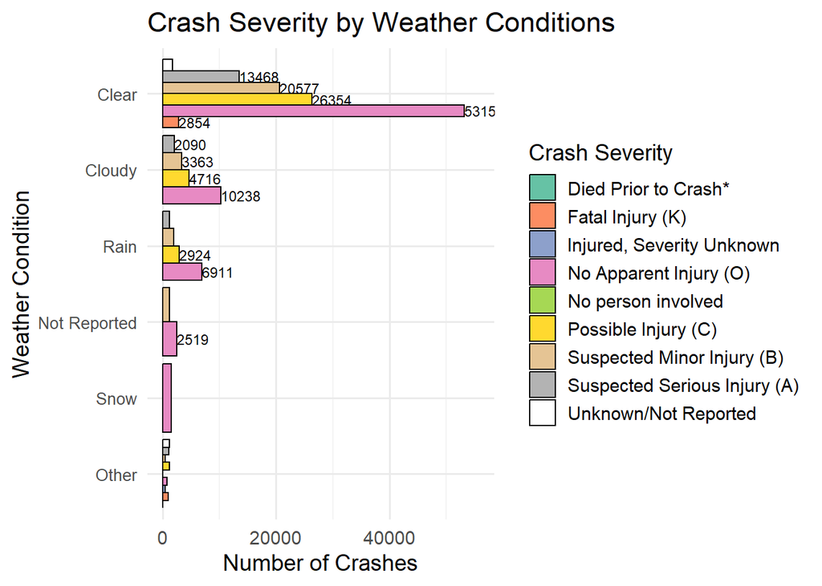

```r
# Clean and group rare weather conditions
weather_severity_clean <- accident %>%
  group_by(WEATHERNAME, MAX_SEVNAME) %>%
  summarise(Count = n(), .groups = "drop") %>%
  mutate(WEATHERNAME = ifelse(Count < 1000, "Other", WEATHERNAME)) %>%
  group_by(WEATHERNAME, MAX_SEVNAME) %>%
  summarise(Count = sum(Count), .groups = "drop")

ggplot(weather_severity_clean,
       aes(x = reorder(WEATHERNAME, Count), y = Count, fill = MAX_SEVNAME)) +
  geom_bar(stat = "identity", position = position_dodge(width = 0.9), color = "black") +
  geom_text(aes(label = ifelse(Count > 2000, Count, "")),
            position = position_dodge(width = 0.9),
            hjust = -0.0, color = "black", size = 3) +
  scale_fill_brewer(palette = "Set2") +
  labs(title = "Crash Severity by Weather Conditions",
       x = "Weather Condition", y = "Number of Crashes", fill = "Crash Severity") +
  coord_flip() +
  theme_minimal(base_size = 14) +
  theme(axis.text.y = element_text(size = 10)) +
  scale_y_continuous(expand = expansion(mult = c(0.05, 0.1)))
```

## Weather Condition Trends Over Time

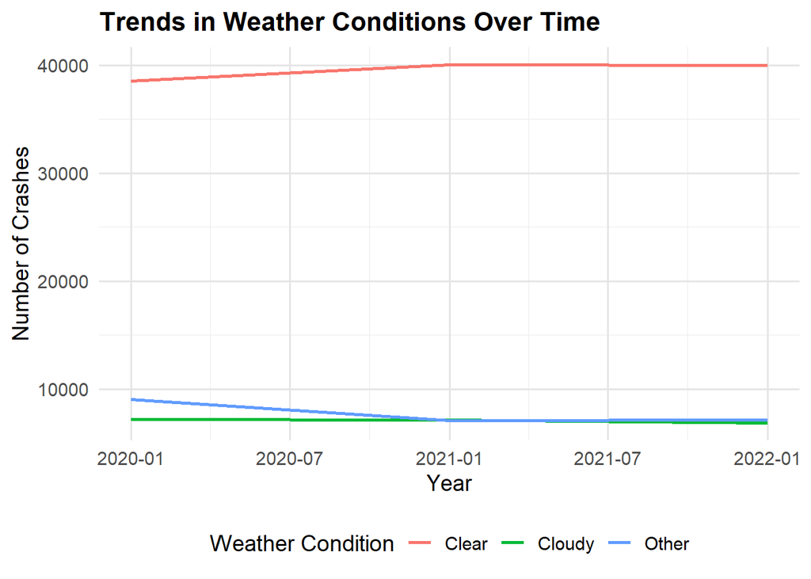

```r
weather_trend_clean <- accident %>%
  mutate(Date = make_date(YEAR)) %>%
  group_by(Date, WEATHERNAME) %>%
  summarise(Count = n(), .groups = "drop") %>%
  mutate(WEATHERNAME = ifelse(Count < 5000, "Other", WEATHERNAME)) %>%
  group_by(Date, WEATHERNAME) %>%
  summarise(Count = sum(Count), .groups = "drop")

ggplot(weather_trend_clean, aes(x = Date, y = Count, color = WEATHERNAME)) +
  geom_line(linewidth = 1) + # Use linewidth instead of size
  labs(title = "Trends in Weather Conditions Over Time",
       x = "Year", y = "Number of Crashes", color = "Weather Condition") +
  theme_minimal(base_size = 14) +
  theme(plot.title = element_text(face = "bold", size = 16),
        panel.grid.major = element_line(color = "grey90"),
        legend.position = "bottom")
```

## Conclusion

Based on the analysis of crash data from 2020–2022 using the CRSS dataset, the following key insights have been identified:

**Crash Severity** The majority of crashes resulted in No Apparent Injury (46.08%), followed by Possible Injury (21.6%) and Suspected Minor Injury (16.92%). Although Fatal Injuries account for only 2.37%, they are more prevalent in rural areas, highlighting a critical area of concern.

**Age Group Distribution** The 20-29 age group had the highest number of participants involved in crashes, with a clear decline observed as age increases. This highlights younger drivers as a high-risk group, potentially due to inexperience, risk-taking behaviors, and lifestyle-related factors.

**Weather Conditions** Most crashes occurred under clear weather conditions (72.74%), while cloudy (13.01%) and rainy conditions (8.25%) contributed to smaller proportions. This indicates complacency during favorable weather, which may lead to reduced vigilance.

**Gender Distribution** Males were significantly overrepresented in crashes, with 213,053 male participants compared to 166,413 females. This may reflect differences in driving patterns, behaviors, and time spent on the road.

**Urban vs. Rural Crashes** Urban areas had the highest number of crashes overall due to higher traffic volumes. However, fatal crashes and severe injuries were proportionally higher in rural areas, which can be attributed to higher driving speeds, longer emergency response times, and poor road infrastructure.

**Trends Over Time** Trends in crash severity remained relatively stable, with “No Apparent Injury” cases showing a slight increase. This likely reflects improvements in vehicle safety features and collision mitigation technologies.

**Crash Severity by Weather** Across weather conditions, clear weather consistently led to the highest number of crashes. Severity patterns did not vary significantly across adverse conditions like rain or snow.

## Recommendations

**Targeted Programs for Young Drivers (20-29 Age Group)** Implement education and training programs focused on reducing risky driving behaviors. Promote defensive driving courses and awareness campaigns targeting younger demographics.

**Rural Road Safety Improvements** Enhance rural infrastructure by improving road quality, lighting, and signage. Deploy emergency response systems and services to ensure faster medical assistance in rural areas. Increase enforcement of speed limits in rural regions to reduce fatal crashes.

**Weather Awareness Campaigns** Launch public campaigns to promote vigilance during clear weather conditions when complacency is higher. Emphasize safe driving practices under all weather conditions, including adverse ones like rain or snow.

**Male Driver Safety Initiatives** Develop gender-specific programs targeting male drivers, who are overrepresented in crashes. Promote campaigns focused on reducing aggressive driving and risky behaviors.

**Ongoing Monitoring and Trends Analysis** Regularly monitor crash trends, especially “No Apparent Injury” cases, to assess the impact of vehicle safety technologies. Incorporate crash severity insights into urban and rural planning strategies to reduce fatalities.